# Risk Factor Analysis

## Outcome Variable

**Outcome Variable:** whz

## Predictor Variables

**Intervention Variable:** exclfeed3

**Adjustment Set:**

unadjusted

## Stratifying Variables

The analysis was stratified on these variable(s):

- agecat
- studyid
- country

## Data Summary

| agecat | studyid | country | exclfeed3 | n_cell | n |
| --- | --- | --- | --- | --- | --- |
| Birth | CMC-V-BCS-2002 | INDIA | 1 | 4 | 4 |
| Birth | CMC-V-BCS-2002 | INDIA | 0 | 0 | 4 |
| Birth | EE | PAKISTAN | 1 | 22 | 22 |
| Birth | EE | PAKISTAN | 0 | 0 | 22 |
| Birth | GMS-Nepal | NEPAL | 1 | 352 | 422 |
| Birth | GMS-Nepal | NEPAL | 0 | 70 | 422 |
| Birth | IRC | INDIA | 1 | 0 | 9 |
| Birth | IRC | INDIA | 0 | 9 | 9 |
| Birth | JiVitA-3 | BANGLADESH | 1 | 9636 | 10634 |
| Birth | JiVitA-3 | BANGLADESH | 0 | 998 | 10634 |
| Birth | JiVitA-4 | BANGLADESH | 1 | 89 | 97 |
| Birth | JiVitA-4 | BANGLADESH | 0 | 8 | 97 |
| Birth | Keneba | GAMBIA | 1 | 1133 | 1282 |
| Birth | Keneba | GAMBIA | 0 | 149 | 1282 |
| Birth | MAL-ED | BANGLADESH | 1 | 130 | 202 |
| Birth | MAL-ED | BANGLADESH | 0 | 72 | 202 |
| Birth | MAL-ED | BRAZIL | 1 | 11 | 55 |
| Birth | MAL-ED | BRAZIL | 0 | 44 | 55 |
| Birth | MAL-ED | INDIA | 1 | 22 | 39 |
| Birth | MAL-ED | INDIA | 0 | 17 | 39 |
| Birth | MAL-ED | NEPAL | 1 | 8 | 25 |
| Birth | MAL-ED | NEPAL | 0 | 17 | 25 |
| Birth | MAL-ED | PERU | 1 | 47 | 218 |
| Birth | MAL-ED | PERU | 0 | 171 | 218 |
| Birth | MAL-ED | SOUTH AFRICA | 1 | 12 | 99 |
| Birth | MAL-ED | SOUTH AFRICA | 0 | 87 | 99 |
| Birth | MAL-ED | TANZANIA, UNITED REPUBLIC OF | 1 | 15 | 95 |
| Birth | MAL-ED | TANZANIA, UNITED REPUBLIC OF | 0 | 80 | 95 |
| Birth | PROVIDE | BANGLADESH | 1 | 381 | 532 |
| Birth | PROVIDE | BANGLADESH | 0 | 151 | 532 |

[output cut: 64 more lines]

The following strata were considered:

- agecat: 24 months, studyid: CMC-V-BCS-2002, country: INDIA
- agecat: 24 months, studyid: EE, country: PAKISTAN
- agecat: 24 months, studyid: GMS-Nepal, country: NEPAL
- agecat: 24 months, studyid: IRC, country: INDIA
- agecat: 24 months, studyid: JiVitA-3, country: BANGLADESH
- agecat: 24 months, studyid: JiVitA-4, country: BANGLADESH
- agecat: 24 months, studyid: Keneba, country: GAMBIA
- agecat: 24 months, studyid: MAL-ED, country: BANGLADESH
- agecat: 24 months, studyid: MAL-ED, country: BRAZIL
- agecat: 24 months, studyid: MAL-ED, country: INDIA
- agecat: 24 months, studyid: MAL-ED, country: NEPAL
- agecat: 24 months, studyid: MAL-ED, country: PERU
- agecat: 24 months, studyid: MAL-ED, country: SOUTH AFRICA
- agecat: 24 months, studyid: MAL-ED, country: TANZANIA, UNITED REPUBLIC OF
- agecat: 24 months, studyid: PROVIDE, country: BANGLADESH
- agecat: 6 months, studyid: CMC-V-BCS-2002, country: INDIA
- agecat: 6 months, studyid: EE, country: PAKISTAN
- agecat: 6 months, studyid: GMS-Nepal, country: NEPAL
- agecat: 6 months, studyid: IRC, country: INDIA
- agecat: 6 months, studyid: JiVitA-3, country: BANGLADESH
- agecat: 6 months, studyid: JiVitA-4, country: BANGLADESH
- agecat: 6 months, studyid: Keneba, country: GAMBIA
- agecat: 6 months, studyid: MAL-ED, country: BANGLADESH
- agecat: 6 months, studyid: MAL-ED, country: BRAZIL
- agecat: 6 months, studyid: MAL-ED, country: INDIA
- agecat: 6 months, studyid: MAL-ED, country: NEPAL
- agecat: 6 months, studyid: MAL-ED, country: PERU
- agecat: 6 months, studyid: MAL-ED, country: SOUTH AFRICA
- agecat: 6 months, studyid: MAL-ED, country: TANZANIA, UNITED REPUBLIC OF
- agecat: 6 months, studyid: PROVIDE, country: BANGLADESH
- agecat: 6 months, studyid: SAS-CompFeed, country: INDIA
- agecat: Birth, studyid: CMC-V-BCS-2002, country: INDIA
- agecat: Birth, studyid: EE, country: PAKISTAN
- agecat: Birth, studyid: GMS-Nepal, country: NEPAL
- agecat: Birth, studyid: IRC, country: INDIA
- agecat: Birth, studyid: JiVitA-3, country: BANGLADESH
- agecat: Birth, studyid: JiVitA-4, country: BANGLADESH
- agecat: Birth, studyid: Keneba, country: GAMBIA
- agecat: Birth, studyid: MAL-ED, country: BANGLADESH
- agecat: Birth, studyid: MAL-ED, country: BRAZIL
- agecat: Birth, studyid: MAL-ED, country: INDIA
- agecat: Birth, studyid: MAL-ED, country: NEPAL
- agecat: Birth, studyid: MAL-ED, country: PERU
- agecat: Birth, studyid: MAL-ED, country: SOUTH AFRICA
- agecat: Birth, studyid: MAL-ED, country: TANZANIA, UNITED REPUBLIC OF
- agecat: Birth, studyid: PROVIDE, country: BANGLADESH
- agecat: Birth, studyid: SAS-CompFeed, country: INDIA

### Dropped Strata

Some strata were dropped due to rare outcomes:

- agecat: Birth, studyid: CMC-V-BCS-2002, country: INDIA
- agecat: Birth, studyid: EE, country: PAKISTAN
- agecat: Birth, studyid: IRC, country: INDIA
- agecat: 6 months, studyid: CMC-V-BCS-2002, country: INDIA
- agecat: 6 months, studyid: EE, country: PAKISTAN
- agecat: 6 months, studyid: IRC, country: INDIA
- agecat: 24 months, studyid: CMC-V-BCS-2002, country: INDIA
- agecat: 24 months, studyid: EE, country: PAKISTAN
- agecat: 24 months, studyid: IRC, country: INDIA

## Methods Detail

We’re interested in the causal parameters $E[Y_a]$ for all values of $a \in \mathcal{A}$. These parameters represent the mean outcome if, possibly contrary to fact, we intervened to set all units to have $A=a$. Under the randomization and positivity assumptions, these are identified by the statistical parameters $\psi_a=E_W[E_{Y|A,W}(Y|A=a,W)]$. In addition, we’re interested in the mean of $Y$, $E[Y]$ under no intervention (the observed mean). We will estimate these parameters by using SuperLearner to fit the relevant likelihood factors – $E_{Y|A,W}(Y|A=a,W)$ and $p(A=a|W)$, and then updating our likelihood fit using a joint TMLE.

For unadjusted analyses ($W=\{\}$), initial likelihoods were estimated using Lrnr_glm to estimate the simple $E(Y|A)$ and Lrnr_mean to estimate $p(A)$. For adjusted analyses, a small library containing Lrnr_glmnet, Lrnr_xgboost, and Lrnr_mean was used.

Having estimated these parameters, we will then use the delta method to estimate relative risks and attributable risks relative to a prespecified baseline level of $A$.

# Results Detail

## Results Plots

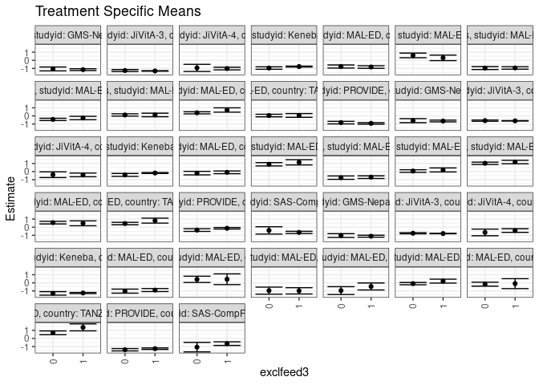

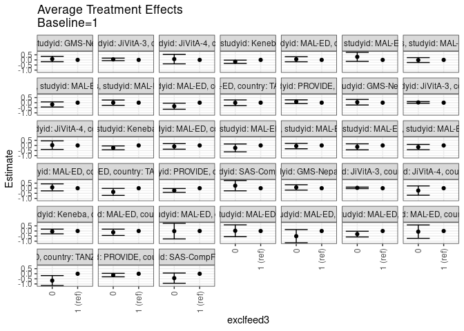

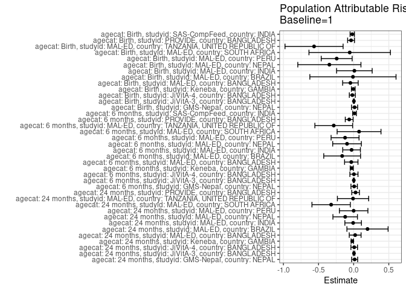

## Results Table

### Parameter: TSM

| agecat | studyid | country | intervention_level | baseline_level | estimate | ci_lower | ci_upper |
| --- | --- | --- | --- | --- | --- | --- | --- |
| Birth | GMS-Nepal | NEPAL | 1 | NA | -1.1124432 | -1.2336464 | -0.9912399 |
| Birth | GMS-Nepal | NEPAL | 0 | NA | -1.0324286 | -1.2641944 | -0.8006628 |
| Birth | JiVitA-3 | BANGLADESH | 1 | NA | -0.7831704 | -0.8064996 | -0.7598412 |
| Birth | JiVitA-3 | BANGLADESH | 0 | NA | -0.7479359 | -0.8173362 | -0.6785355 |
| Birth | JiVitA-4 | BANGLADESH | 1 | NA | -0.4156180 | -0.6383645 | -0.1928714 |
| Birth | JiVitA-4 | BANGLADESH | 0 | NA | -0.6475000 | -1.0569566 | -0.2380434 |
| Birth | Keneba | GAMBIA | 1 | NA | -1.2574448 | -1.3266766 | -1.1882131 |
| Birth | Keneba | GAMBIA | 0 | NA | -1.3048658 | -1.5220783 | -1.0876532 |
| Birth | MAL-ED | BANGLADESH | 1 | NA | -0.8949231 | -1.0792337 | -0.7106124 |
| Birth | MAL-ED | BANGLADESH | 0 | NA | -1.0245833 | -1.2736100 | -0.7755567 |
| Birth | MAL-ED | BRAZIL | 1 | NA | 0.4418182 | -0.2215612 | 1.1051976 |
| Birth | MAL-ED | BRAZIL | 0 | NA | 0.4290909 | 0.0450384 | 0.8131434 |
| Birth | MAL-ED | INDIA | 1 | NA | -0.9881818 | -1.3731602 | -0.6032035 |
| Birth | MAL-ED | INDIA | 0 | NA | -0.9647059 | -1.4004407 | -0.5289711 |
| Birth | MAL-ED | NEPAL | 1 | NA | -0.4487500 | -0.8783289 | -0.0191711 |
| Birth | MAL-ED | NEPAL | 0 | NA | -0.9570588 | -1.4394884 | -0.4746293 |
| Birth | MAL-ED | PERU | 1 | NA | 0.2078723 | -0.0344923 | 0.4502370 |
| Birth | MAL-ED | PERU | 0 | NA | -0.0998830 | -0.2401451 | 0.0403790 |
| Birth | MAL-ED | SOUTH AFRICA | 1 | NA | -0.1025000 | -0.7159377 | 0.5109377 |
| Birth | MAL-ED | SOUTH AFRICA | 0 | NA | -0.1666667 | -0.4090416 | 0.0757083 |
| Birth | MAL-ED | TANZANIA, UNITED REPUBLIC OF | 1 | NA | 1.3633333 | 0.9342962 | 1.7923704 |
| Birth | MAL-ED | TANZANIA, UNITED REPUBLIC OF | 0 | NA | 0.6940000 | 0.4624928 | 0.9255072 |
| Birth | PROVIDE | BANGLADESH | 1 | NA | -1.2615223 | -1.3516334 | -1.1714113 |
| Birth | PROVIDE | BANGLADESH | 0 | NA | -1.3916556 | -1.5374010 | -1.2459103 |
| Birth | SAS-CompFeed | INDIA | 1 | NA | -0.6397097 | -0.8621395 | -0.4172798 |
| Birth | SAS-CompFeed | INDIA | 0 | NA | -1.0713333 | -1.6580583 | -0.4846084 |
| 6 months | GMS-Nepal | NEPAL | 1 | NA | -0.6271798 | -0.7373913 | -0.5169683 |
| 6 months | GMS-Nepal | NEPAL | 0 | NA | -0.5836712 | -0.8323071 | -0.3350353 |
| 6 months | JiVitA-3 | BANGLADESH | 1 | NA | -0.6060595 | -0.6317365 | -0.5803826 |
| 6 months | JiVitA-3 | BANGLADESH | 0 | NA | -0.5835388 | -0.6624509 | -0.5046268 |
| 6 months | JiVitA-4 | BANGLADESH | 1 | NA | -0.4150000 | -0.6422302 | -0.1877698 |
| 6 months | JiVitA-4 | BANGLADESH | 0 | NA | -0.3858333 | -0.7373291 | -0.0343375 |
| 6 months | Keneba | GAMBIA | 1 | NA | -0.1784105 | -0.2368092 | -0.1200118 |
| 6 months | Keneba | GAMBIA | 0 | NA | -0.4150779 | -0.5933349 | -0.2368209 |
| 6 months | MAL-ED | BANGLADESH | 1 | NA | -0.0965022 | -0.2621967 | 0.0691923 |
| 6 months | MAL-ED | BANGLADESH | 0 | NA | -0.1942798 | -0.4117749 | 0.0232152 |
| 6 months | MAL-ED | BRAZIL | 1 | NA | 1.1392778 | 0.8156735 | 1.4628820 |
| 6 months | MAL-ED | BRAZIL | 0 | NA | 0.8979987 | 0.6894708 | 1.1065266 |
| 6 months | MAL-ED | INDIA | 1 | NA | -0.6888561 | -0.8509420 | -0.5267701 |
| 6 months | MAL-ED | INDIA | 0 | NA | -0.7513167 | -0.9593805 | -0.5432529 |
| 6 months | MAL-ED | NEPAL | 1 | NA | 0.1985476 | -0.0480370 | 0.4451322 |
| 6 months | MAL-ED | NEPAL | 0 | NA | 0.0620594 | -0.0992827 | 0.2234016 |
| 6 months | MAL-ED | PERU | 1 | NA | 1.1737295 | 0.9621747 | 1.3852843 |
| 6 months | MAL-ED | PERU | 0 | NA | 1.0157137 | 0.8703660 | 1.1610615 |
| 6 months | MAL-ED | SOUTH AFRICA | 1 | NA | 0.4793939 | 0.1776578 | 0.7811301 |
| 6 months | MAL-ED | SOUTH AFRICA | 0 | NA | 0.5640390 | 0.4009538 | 0.7271242 |
| 6 months | MAL-ED | TANZANIA, UNITED REPUBLIC OF | 1 | NA | 0.8092391 | 0.5033830 | 1.1150953 |
| 6 months | MAL-ED | TANZANIA, UNITED REPUBLIC OF | 0 | NA | 0.4472088 | 0.2939423 | 0.6004754 |
| 6 months | PROVIDE | BANGLADESH | 1 | NA | -0.1355179 | -0.2298689 | -0.0411669 |
| 6 months | PROVIDE | BANGLADESH | 0 | NA | -0.3545714 | -0.5195489 | -0.1895939 |
| 6 months | SAS-CompFeed | INDIA | 1 | NA | -0.6469149 | -0.7835786 | -0.5102511 |
| 6 months | SAS-CompFeed | INDIA | 0 | NA | -0.3968421 | -0.8495292 | 0.0558450 |
| 24 months | GMS-Nepal | NEPAL | 1 | NA | -1.1537474 | -1.2663233 | -1.0411715 |
| 24 months | GMS-Nepal | NEPAL | 0 | NA | -1.0663978 | -1.3047957 | -0.8280000 |
| 24 months | JiVitA-3 | BANGLADESH | 1 | NA | -1.3153736 | -1.3472789 | -1.2834684 |
| 24 months | JiVitA-3 | BANGLADESH | 0 | NA | -1.2641247 | -1.3841034 | -1.1441460 |
| 24 months | JiVitA-4 | BANGLADESH | 1 | NA | -1.0175556 | -1.1803689 | -0.8547422 |
| 24 months | JiVitA-4 | BANGLADESH | 0 | NA | -0.9380000 | -1.3723208 | -0.5036792 |
| 24 months | Keneba | GAMBIA | 1 | NA | -0.7741136 | -0.8283859 | -0.7198412 |
| 24 months | Keneba | GAMBIA | 0 | NA | -0.9575771 | -1.1080094 | -0.8071448 |
| 24 months | MAL-ED | BANGLADESH | 1 | NA | -0.8290370 | -0.9859194 | -0.6721547 |
| 24 months | MAL-ED | BANGLADESH | 0 | NA | -0.7665000 | -0.9557893 | -0.5772107 |
| 24 months | MAL-ED | BRAZIL | 1 | NA | 0.3010577 | -0.0393674 | 0.6414828 |
| 24 months | MAL-ED | BRAZIL | 0 | NA | 0.6005833 | 0.3152474 | 0.8859193 |
| 24 months | MAL-ED | INDIA | 1 | NA | -0.9442647 | -1.0954140 | -0.7931155 |
| 24 months | MAL-ED | INDIA | 0 | NA | -0.9592500 | -1.1429089 | -0.7755911 |
| 24 months | MAL-ED | NEPAL | 1 | NA | -0.2583582 | -0.4657222 | -0.0509942 |
| 24 months | MAL-ED | NEPAL | 0 | NA | -0.4318954 | -0.5724256 | -0.2913652 |
| 24 months | MAL-ED | PERU | 1 | NA | 0.1178101 | -0.1002228 | 0.3358429 |
| 24 months | MAL-ED | PERU | 0 | NA | 0.1175484 | -0.0220882 | 0.2571850 |
| 24 months | MAL-ED | SOUTH AFRICA | 1 | NA | 0.7323684 | 0.4646052 | 1.0001317 |
| 24 months | MAL-ED | SOUTH AFRICA | 0 | NA | 0.3829625 | 0.2528522 | 0.5130729 |
| 24 months | MAL-ED | TANZANIA, UNITED REPUBLIC OF | 1 | NA | 0.0584211 | -0.1721451 | 0.2889872 |
| 24 months | MAL-ED | TANZANIA, UNITED REPUBLIC OF | 0 | NA | 0.0472717 | -0.1123699 | 0.2069132 |
| 24 months | PROVIDE | BANGLADESH | 1 | NA | -0.9202574 | -1.0173798 | -0.8231349 |
| 24 months | PROVIDE | BANGLADESH | 0 | NA | -0.8275146 | -0.9839667 | -0.6710626 |

### Parameter: E(Y)

| agecat | studyid | country | intervention_level | baseline_level | estimate | ci_lower | ci_upper |
| --- | --- | --- | --- | --- | --- | --- | --- |
| Birth | GMS-Nepal | NEPAL | NA | NA | -1.0991706 | -1.2073693 | -0.9909719 |
| Birth | JiVitA-3 | BANGLADESH | NA | NA | -0.7798636 | -0.8022140 | -0.7575133 |
| Birth | JiVitA-4 | BANGLADESH | NA | NA | -0.4347423 | -0.6441144 | -0.2253701 |
| Birth | Keneba | GAMBIA | NA | NA | -1.2629563 | -1.3291505 | -1.1967622 |
| Birth | MAL-ED | BANGLADESH | NA | NA | -0.9411386 | -1.0895370 | -0.7927402 |
| Birth | MAL-ED | BRAZIL | NA | NA | 0.4316364 | 0.0969688 | 0.7663039 |
| Birth | MAL-ED | INDIA | NA | NA | -0.9779487 | -1.2664810 | -0.6894164 |
| Birth | MAL-ED | NEPAL | NA | NA | -0.7944000 | -1.1625222 | -0.4262778 |
| Birth | MAL-ED | PERU | NA | NA | -0.0335321 | -0.1564905 | 0.0894263 |
| Birth | MAL-ED | SOUTH AFRICA | NA | NA | -0.1588889 | -0.3845288 | 0.0667510 |
| Birth | MAL-ED | TANZANIA, UNITED REPUBLIC OF | NA | NA | 0.7996842 | 0.5874808 | 1.0118876 |
| Birth | PROVIDE | BANGLADESH | NA | NA | -1.2984586 | -1.3752758 | -1.2216415 |
| Birth | SAS-CompFeed | INDIA | NA | NA | -0.6596308 | -0.9005716 | -0.4186900 |
| 6 months | GMS-Nepal | NEPAL | NA | NA | -0.6198791 | -0.7206518 | -0.5191063 |
| 6 months | JiVitA-3 | BANGLADESH | NA | NA | -0.6040977 | -0.6286619 | -0.5795335 |
| 6 months | JiVitA-4 | BANGLADESH | NA | NA | -0.4110227 | -0.6122701 | -0.2097753 |
| 6 months | Keneba | GAMBIA | NA | NA | -0.2057183 | -0.2614359 | -0.1500006 |
| 6 months | MAL-ED | BANGLADESH | NA | NA | -0.1304936 | -0.2625419 | 0.0015547 |
| 6 months | MAL-ED | BRAZIL | NA | NA | 0.9754144 | 0.7990651 | 1.1517638 |
| 6 months | MAL-ED | INDIA | NA | NA | -0.7185992 | -0.8491469 | -0.5880515 |
| 6 months | MAL-ED | NEPAL | NA | NA | 0.1041483 | -0.0311352 | 0.2394318 |
| 6 months | MAL-ED | PERU | NA | NA | 1.0514136 | 0.9289176 | 1.1739096 |
| 6 months | MAL-ED | SOUTH AFRICA | NA | NA | 0.5564071 | 0.4055220 | 0.7072922 |
| 6 months | MAL-ED | TANZANIA, UNITED REPUBLIC OF | NA | NA | 0.5257626 | 0.3871543 | 0.6643709 |
| 6 months | PROVIDE | BANGLADESH | NA | NA | -0.1990907 | -0.2817968 | -0.1163845 |
| 6 months | SAS-CompFeed | INDIA | NA | NA | -0.6348861 | -0.7630511 | -0.5067211 |
| 24 months | GMS-Nepal | NEPAL | NA | NA | -1.1396441 | -1.2416403 | -1.0376479 |
| 24 months | JiVitA-3 | BANGLADESH | NA | NA | -1.3109518 | -1.3423299 | -1.2795737 |
| 24 months | JiVitA-4 | BANGLADESH | NA | NA | -1.0096000 | -1.1619164 | -0.8572836 |
| 24 months | Keneba | GAMBIA | NA | NA | -0.7930925 | -0.8442611 | -0.7419240 |
| 24 months | MAL-ED | BANGLADESH | NA | NA | -0.8076829 | -0.9296166 | -0.6857493 |
| 24 months | MAL-ED | BRAZIL | NA | NA | 0.4981140 | 0.2760418 | 0.7201863 |
| 24 months | MAL-ED | INDIA | NA | NA | -0.9516832 | -1.0703961 | -0.8329703 |
| 24 months | MAL-ED | NEPAL | NA | NA | -0.3790455 | -0.4958857 | -0.2622052 |
| 24 months | MAL-ED | PERU | NA | NA | 0.1176052 | -0.0015211 | 0.2367315 |
| 24 months | MAL-ED | SOUTH AFRICA | NA | NA | 0.4120797 | 0.2900939 | 0.5340654 |
| 24 months | MAL-ED | TANZANIA, UNITED REPUBLIC OF | NA | NA | 0.0495743 | -0.0857535 | 0.1849021 |
| 24 months | PROVIDE | BANGLADESH | NA | NA | -0.8928670 | -0.9755153 | -0.8102187 |

### Parameter: ATE

| agecat | studyid | country | intervention_level | baseline_level | estimate | ci_lower | ci_upper |
| --- | --- | --- | --- | --- | --- | --- | --- |
| Birth | GMS-Nepal | NEPAL | 1 | 1 | 0.0000000 | 0.0000000 | 0.0000000 |
| Birth | GMS-Nepal | NEPAL | 0 | 1 | 0.0800146 | -0.1815301 | 0.3415593 |
| Birth | JiVitA-3 | BANGLADESH | 1 | 1 | 0.0000000 | 0.0000000 | 0.0000000 |
| Birth | JiVitA-3 | BANGLADESH | 0 | 1 | 0.0352345 | -0.0371355 | 0.1076046 |
| Birth | JiVitA-4 | BANGLADESH | 1 | 1 | 0.0000000 | 0.0000000 | 0.0000000 |
| Birth | JiVitA-4 | BANGLADESH | 0 | 1 | -0.2318820 | -0.6871466 | 0.2233826 |
| Birth | Keneba | GAMBIA | 1 | 1 | 0.0000000 | 0.0000000 | 0.0000000 |
| Birth | Keneba | GAMBIA | 0 | 1 | -0.0474209 | -0.2753997 | 0.1805578 |
| Birth | MAL-ED | BANGLADESH | 1 | 1 | 0.0000000 | 0.0000000 | 0.0000000 |
| Birth | MAL-ED | BANGLADESH | 0 | 1 | -0.1296603 | -0.4394742 | 0.1801537 |
| Birth | MAL-ED | BRAZIL | 1 | 1 | 0.0000000 | 0.0000000 | 0.0000000 |
| Birth | MAL-ED | BRAZIL | 0 | 1 | -0.0127273 | -0.7792575 | 0.7538029 |
| Birth | MAL-ED | INDIA | 1 | 1 | 0.0000000 | 0.0000000 | 0.0000000 |
| Birth | MAL-ED | INDIA | 0 | 1 | 0.0234759 | -0.5579646 | 0.6049165 |
| Birth | MAL-ED | NEPAL | 1 | 1 | 0.0000000 | 0.0000000 | 0.0000000 |
| Birth | MAL-ED | NEPAL | 0 | 1 | -0.5083088 | -1.1542781 | 0.1376604 |
| Birth | MAL-ED | PERU | 1 | 1 | 0.0000000 | 0.0000000 | 0.0000000 |
| Birth | MAL-ED | PERU | 0 | 1 | -0.3077554 | -0.5877805 | -0.0277302 |
| Birth | MAL-ED | SOUTH AFRICA | 1 | 1 | 0.0000000 | 0.0000000 | 0.0000000 |
| Birth | MAL-ED | SOUTH AFRICA | 0 | 1 | -0.0641667 | -0.7237510 | 0.5954176 |
| Birth | MAL-ED | TANZANIA, UNITED REPUBLIC OF | 1 | 1 | 0.0000000 | 0.0000000 | 0.0000000 |
| Birth | MAL-ED | TANZANIA, UNITED REPUBLIC OF | 0 | 1 | -0.6693333 | -1.1568458 | -0.1818209 |
| Birth | PROVIDE | BANGLADESH | 1 | 1 | 0.0000000 | 0.0000000 | 0.0000000 |
| Birth | PROVIDE | BANGLADESH | 0 | 1 | -0.1301333 | -0.3014859 | 0.0412193 |
| Birth | SAS-CompFeed | INDIA | 1 | 1 | 0.0000000 | 0.0000000 | 0.0000000 |
| Birth | SAS-CompFeed | INDIA | 0 | 1 | -0.4316237 | -0.9347060 | 0.0714587 |
| 6 months | GMS-Nepal | NEPAL | 1 | 1 | 0.0000000 | 0.0000000 | 0.0000000 |
| 6 months | GMS-Nepal | NEPAL | 0 | 1 | 0.0435087 | -0.2284590 | 0.3154763 |
| 6 months | JiVitA-3 | BANGLADESH | 1 | 1 | 0.0000000 | 0.0000000 | 0.0000000 |
| 6 months | JiVitA-3 | BANGLADESH | 0 | 1 | 0.0225207 | -0.0599877 | 0.1050291 |
| 6 months | JiVitA-4 | BANGLADESH | 1 | 1 | 0.0000000 | 0.0000000 | 0.0000000 |
| 6 months | JiVitA-4 | BANGLADESH | 0 | 1 | 0.0291667 | -0.3927898 | 0.4511231 |
| 6 months | Keneba | GAMBIA | 1 | 1 | 0.0000000 | 0.0000000 | 0.0000000 |
| 6 months | Keneba | GAMBIA | 0 | 1 | -0.2366675 | -0.4242467 | -0.0490882 |
| 6 months | MAL-ED | BANGLADESH | 1 | 1 | 0.0000000 | 0.0000000 | 0.0000000 |
| 6 months | MAL-ED | BANGLADESH | 0 | 1 | -0.0977776 | -0.3711981 | 0.1756428 |
| 6 months | MAL-ED | BRAZIL | 1 | 1 | 0.0000000 | 0.0000000 | 0.0000000 |
| 6 months | MAL-ED | BRAZIL | 0 | 1 | -0.2412791 | -0.6262513 | 0.1436931 |
| 6 months | MAL-ED | INDIA | 1 | 1 | 0.0000000 | 0.0000000 | 0.0000000 |
| 6 months | MAL-ED | INDIA | 0 | 1 | -0.0624606 | -0.3262074 | 0.2012862 |
| 6 months | MAL-ED | NEPAL | 1 | 1 | 0.0000000 | 0.0000000 | 0.0000000 |
| 6 months | MAL-ED | NEPAL | 0 | 1 | -0.1364882 | -0.4311664 | 0.1581900 |
| 6 months | MAL-ED | PERU | 1 | 1 | 0.0000000 | 0.0000000 | 0.0000000 |
| 6 months | MAL-ED | PERU | 0 | 1 | -0.1580158 | -0.4146895 | 0.0986579 |
| 6 months | MAL-ED | SOUTH AFRICA | 1 | 1 | 0.0000000 | 0.0000000 | 0.0000000 |
| 6 months | MAL-ED | SOUTH AFRICA | 0 | 1 | 0.0846451 | -0.2583439 | 0.4276341 |
| 6 months | MAL-ED | TANZANIA, UNITED REPUBLIC OF | 1 | 1 | 0.0000000 | 0.0000000 | 0.0000000 |
| 6 months | MAL-ED | TANZANIA, UNITED REPUBLIC OF | 0 | 1 | -0.3620303 | -0.7041394 | -0.0199212 |
| 6 months | PROVIDE | BANGLADESH | 1 | 1 | 0.0000000 | 0.0000000 | 0.0000000 |
| 6 months | PROVIDE | BANGLADESH | 0 | 1 | -0.2190535 | -0.4091053 | -0.0290017 |
| 6 months | SAS-CompFeed | INDIA | 1 | 1 | 0.0000000 | 0.0000000 | 0.0000000 |
| 6 months | SAS-CompFeed | INDIA | 0 | 1 | 0.2500728 | -0.2551626 | 0.7553082 |
| 24 months | GMS-Nepal | NEPAL | 1 | 1 | 0.0000000 | 0.0000000 | 0.0000000 |
| 24 months | GMS-Nepal | NEPAL | 0 | 1 | 0.0873496 | -0.1762920 | 0.3509911 |
| 24 months | JiVitA-3 | BANGLADESH | 1 | 1 | 0.0000000 | 0.0000000 | 0.0000000 |
| 24 months | JiVitA-3 | BANGLADESH | 0 | 1 | 0.0512489 | -0.0713920 | 0.1738899 |
| 24 months | JiVitA-4 | BANGLADESH | 1 | 1 | 0.0000000 | 0.0000000 | 0.0000000 |
| 24 months | JiVitA-4 | BANGLADESH | 0 | 1 | 0.0795556 | -0.3867351 | 0.5458462 |
| 24 months | Keneba | GAMBIA | 1 | 1 | 0.0000000 | 0.0000000 | 0.0000000 |
| 24 months | Keneba | GAMBIA | 0 | 1 | -0.1834635 | -0.3433866 | -0.0235405 |
| 24 months | MAL-ED | BANGLADESH | 1 | 1 | 0.0000000 | 0.0000000 | 0.0000000 |
| 24 months | MAL-ED | BANGLADESH | 0 | 1 | 0.0625370 | -0.1833135 | 0.3083876 |
| 24 months | MAL-ED | BRAZIL | 1 | 1 | 0.0000000 | 0.0000000 | 0.0000000 |
| 24 months | MAL-ED | BRAZIL | 0 | 1 | 0.2995256 | -0.1446656 | 0.7437169 |
| 24 months | MAL-ED | INDIA | 1 | 1 | 0.0000000 | 0.0000000 | 0.0000000 |
| 24 months | MAL-ED | INDIA | 0 | 1 | -0.0149853 | -0.2528439 | 0.2228733 |
| 24 months | MAL-ED | NEPAL | 1 | 1 | 0.0000000 | 0.0000000 | 0.0000000 |
| 24 months | MAL-ED | NEPAL | 0 | 1 | -0.1735372 | -0.4240339 | 0.0769595 |
| 24 months | MAL-ED | PERU | 1 | 1 | 0.0000000 | 0.0000000 | 0.0000000 |
| 24 months | MAL-ED | PERU | 0 | 1 | -0.0002617 | -0.2591762 | 0.2586528 |
| 24 months | MAL-ED | SOUTH AFRICA | 1 | 1 | 0.0000000 | 0.0000000 | 0.0000000 |
| 24 months | MAL-ED | SOUTH AFRICA | 0 | 1 | -0.3494059 | -0.6471069 | -0.0517049 |
| 24 months | MAL-ED | TANZANIA, UNITED REPUBLIC OF | 1 | 1 | 0.0000000 | 0.0000000 | 0.0000000 |
| 24 months | MAL-ED | TANZANIA, UNITED REPUBLIC OF | 0 | 1 | -0.0111494 | -0.2915886 | 0.2692899 |
| 24 months | PROVIDE | BANGLADESH | 1 | 1 | 0.0000000 | 0.0000000 | 0.0000000 |
| 24 months | PROVIDE | BANGLADESH | 0 | 1 | 0.0927427 | -0.0914040 | 0.2768894 |

### Parameter: PAR

| agecat | studyid | country | intervention_level | baseline_level | estimate | ci_lower | ci_upper |
| --- | --- | --- | --- | --- | --- | --- | --- |
| Birth | GMS-Nepal | NEPAL | 1 | NA | 0.0132726 | -0.0302047 | 0.0567498 |
| Birth | JiVitA-3 | BANGLADESH | 1 | NA | 0.0033068 | -0.0035158 | 0.0101293 |
| Birth | JiVitA-4 | BANGLADESH | 1 | NA | -0.0191243 | -0.0615870 | 0.0233385 |
| Birth | Keneba | GAMBIA | 1 | NA | -0.0055115 | -0.0320213 | 0.0209983 |
| Birth | MAL-ED | BANGLADESH | 1 | NA | -0.0462155 | -0.1569775 | 0.0645464 |
| Birth | MAL-ED | BRAZIL | 1 | NA | -0.0101818 | -0.6234075 | 0.6030438 |
| Birth | MAL-ED | INDIA | 1 | NA | 0.0102331 | -0.2432424 | 0.2637086 |
| Birth | MAL-ED | NEPAL | 1 | NA | -0.3456500 | -0.7950359 | 0.1037359 |
| Birth | MAL-ED | PERU | 1 | NA | -0.2414045 | -0.4617017 | -0.0211072 |
| Birth | MAL-ED | SOUTH AFRICA | 1 | NA | -0.0563889 | -0.6360384 | 0.5232606 |
| Birth | MAL-ED | TANZANIA, UNITED REPUBLIC OF | 1 | NA | -0.5636491 | -0.9771402 | -0.1501581 |
| Birth | PROVIDE | BANGLADESH | 1 | NA | -0.0369363 | -0.0858275 | 0.0119548 |
| Birth | SAS-CompFeed | INDIA | 1 | NA | -0.0199211 | -0.0507808 | 0.0109386 |
| 6 months | GMS-Nepal | NEPAL | 1 | NA | 0.0073008 | -0.0383608 | 0.0529623 |
| 6 months | JiVitA-3 | BANGLADESH | 1 | NA | 0.0019618 | -0.0052137 | 0.0091373 |
| 6 months | JiVitA-4 | BANGLADESH | 1 | NA | 0.0039773 | -0.0536508 | 0.0616053 |
| 6 months | Keneba | GAMBIA | 1 | NA | -0.0273078 | -0.0492410 | -0.0053745 |
| 6 months | MAL-ED | BANGLADESH | 1 | NA | -0.0339914 | -0.1292318 | 0.0612491 |
| 6 months | MAL-ED | BRAZIL | 1 | NA | -0.1638633 | -0.4258156 | 0.0980889 |
| 6 months | MAL-ED | INDIA | 1 | NA | -0.0297431 | -0.1554081 | 0.0959218 |
| 6 months | MAL-ED | NEPAL | 1 | NA | -0.0943993 | -0.2983732 | 0.1095746 |
| 6 months | MAL-ED | PERU | 1 | NA | -0.1223159 | -0.3211573 | 0.0765254 |
| 6 months | MAL-ED | SOUTH AFRICA | 1 | NA | 0.0770132 | -0.2350655 | 0.3890918 |
| 6 months | MAL-ED | TANZANIA, UNITED REPUBLIC OF | 1 | NA | -0.2834766 | -0.5521101 | -0.0148430 |
| 6 months | PROVIDE | BANGLADESH | 1 | NA | -0.0635727 | -0.1192976 | -0.0078479 |
| 6 months | SAS-CompFeed | INDIA | 1 | NA | 0.0120288 | -0.0145556 | 0.0386132 |
| 24 months | GMS-Nepal | NEPAL | 1 | NA | 0.0141033 | -0.0285853 | 0.0567920 |
| 24 months | JiVitA-3 | BANGLADESH | 1 | NA | 0.0044219 | -0.0061248 | 0.0149685 |
| 24 months | JiVitA-4 | BANGLADESH | 1 | NA | 0.0079556 | -0.0390048 | 0.0549159 |
| 24 months | Keneba | GAMBIA | 1 | NA | -0.0189790 | -0.0357760 | -0.0021819 |
| 24 months | MAL-ED | BANGLADESH | 1 | NA | 0.0213541 | -0.0626934 | 0.1054017 |
| 24 months | MAL-ED | BRAZIL | 1 | NA | 0.1970563 | -0.0960523 | 0.4901650 |
| 24 months | MAL-ED | INDIA | 1 | NA | -0.0074185 | -0.1251748 | 0.1103379 |
| 24 months | MAL-ED | NEPAL | 1 | NA | -0.1206872 | -0.2952171 | 0.0538426 |
| 24 months | MAL-ED | PERU | 1 | NA | -0.0002049 | -0.2028904 | 0.2024807 |
| 24 months | MAL-ED | SOUTH AFRICA | 1 | NA | -0.3202887 | -0.5934703 | -0.0471072 |
| 24 months | MAL-ED | TANZANIA, UNITED REPUBLIC OF | 1 | NA | -0.0088468 | -0.2313702 | 0.2136766 |
| 24 months | PROVIDE | BANGLADESH | 1 | NA | 0.0273903 | -0.0271042 | 0.0818849 |